# Exploratory Data Visualization

Mahbubul Majumder, PhD  
Sep 9, 2014

### Exploratory data analysis (EDA)

- Learn about underlying structure of the data
- Identify the variables (could be hidden !)
- Potential outliers or anomalies with the data
- Missing or systematic pattern in the data
- Discover the unexpected
- How valuable the data is to answer the potential question
- Identify features the model can't find
- Identify whether assumptions of a model is satisfied

### Tips data: a case study

- Cook et. al.: Interactive and Dynamic Graphics for Data Analysis
- Does the tip rate depend on the size?

```r
tips <- read.csv("http://www.ggobi.org/book/data/tips.csv")
tips$rate <- with(tips,tip/totbill)
model <- lm(rate~size, data=tips)
summary(model)$coefficients
```

```
             Estimate Std. Error t value  Pr(>|t|)
(Intercept)  0.184375   0.011191  16.475 2.094e-41
size        -0.009173   0.004085  -2.245 2.565e-02
```

- When the party size increases by 1 person, tip rate decreases by about 1%  
  tip rate = 0.18 - 0.01 * size

### Tips data: explore the tips

- Let us explore the distribution of tips

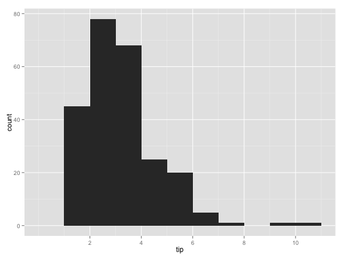

```r
library(ggplot2)
ggplot(tips) +
  geom_histogram(aes(tip), binwidth=1) +
  scale_x_continuous(
    breaks=seq(2,10,by=2))
```

- Now change the binwidth to .1

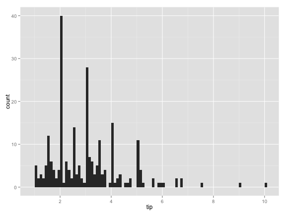

```r
library(ggplot2)
ggplot(tips) + geom_histogram(aes(tip), binwidth=0.1)+
  scale_x_continuous(
    breaks=seq(2,10,by=2))
```

### Tips data: explore the relationship

- Adding layer

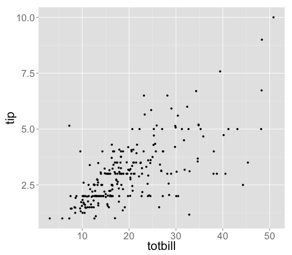

```r
ggplot(tips,
       aes(totbill,tip)) +
  geom_point()
```

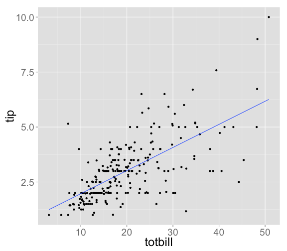

```r
ggplot(tips,
       aes(totbill,tip)) +
  geom_point() +
  geom_smooth(method="lm", se=F)
```

### Tips data: include more variables

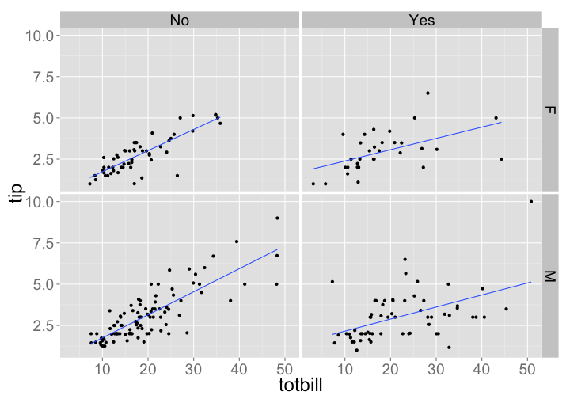

```r
ggplot(tips,
       aes(totbill,tip)) +
  geom_point() +
  geom_smooth(method="lm", se=F) +
  facet_grid(sex~smoker)
```

### Tips data: fun in exploring

- Exploratory study reveals more interesting features
- Model was not giving those insights
- How was it possible?
  - building a complex plot piece by piece
  - it did not take too much to get to next level of complexity
  - gives flexibilities in whatever next level could be
  - provides interface to include many other sets of data layers
  - there should be a standard procedure
- let us learn it now or never

### Grammar of graphics

- Leland Wilkinson (1999)
  - grammar of graphics
- Hadley Whickham (2005)
  - continued working with the grammar
  - implemented in `R`:
  - layered grammar of graphics (2010)

```r
  install.packages("ggplot2")
  library(ggplot2)
```

- poetry of graphics

### gg Basics

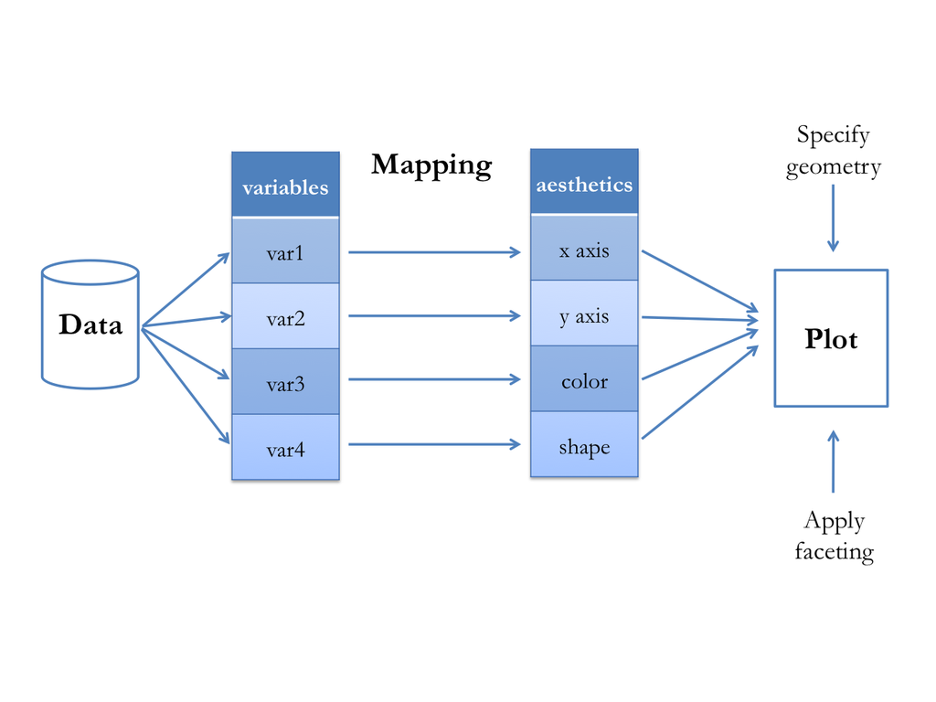

**Note:** One variable could be mapped to multiple aesthetics

### Creating a plot piece by piece

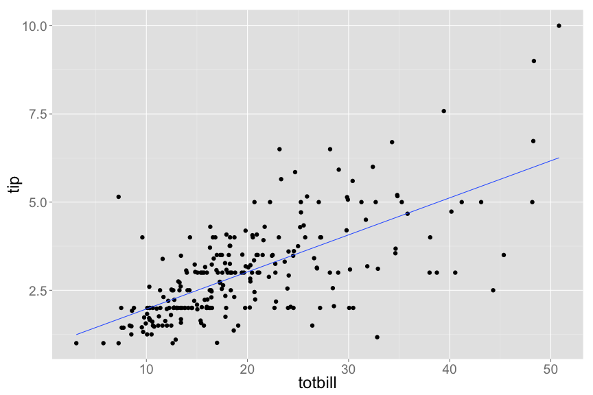

```r
p <- ggplot(data=tips, aes(x=totbill,y=tip))
p + geom_point(size=3) + geom_smooth(method="lm", se=F)
```

### Creating a plot piece by piece

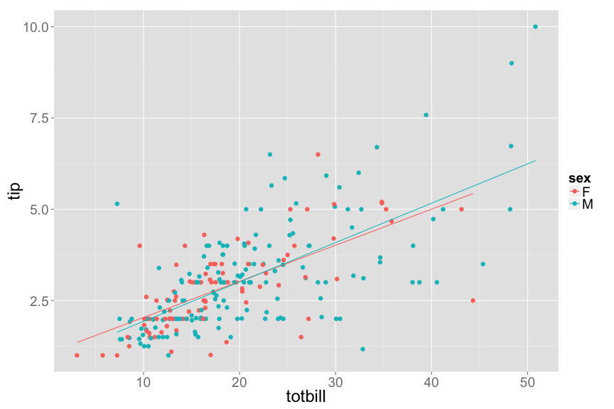

```r
p <- ggplot(data=tips, aes(x=totbill,y=tip,color=sex))
p + geom_point(size=3) + geom_smooth(method="lm", se=F)
```

### Creating a plot piece by piece

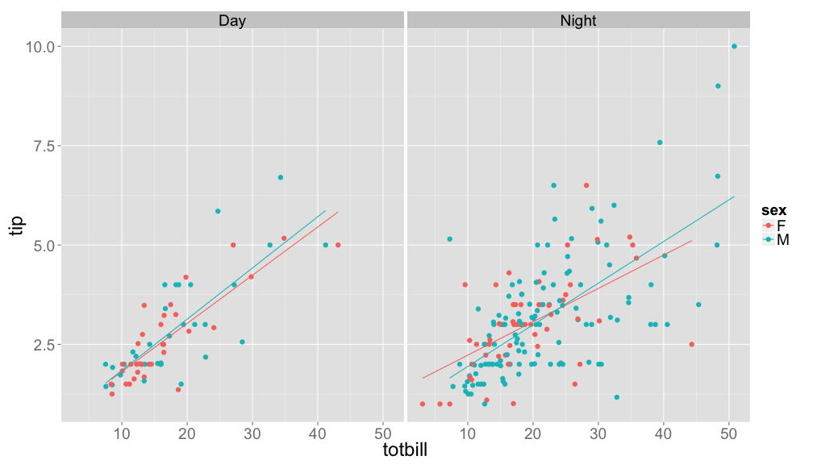

```r
p + geom_point(size=3) + geom_smooth(method="lm",se=F) + facet_wrap(~time)
```

### Some useful functions

- Geometric functions:  
  `geom_point() geom_line() geom_bar() geom_histogram() geom_density() geom_boxplot()`
- Statistics:  
  `stat_smooth() stat_quantile()`
- Faceting:  
  `facet_wrap() facet_grid()`
- Scaling:  
  `scale_x_continuous() scale_y_continuous()`
- Theme:  
  `theme_bw() theme_gray()`
- For more please visit http://docs.ggplot2.org/current/index.html

### Example: multilayer and theme

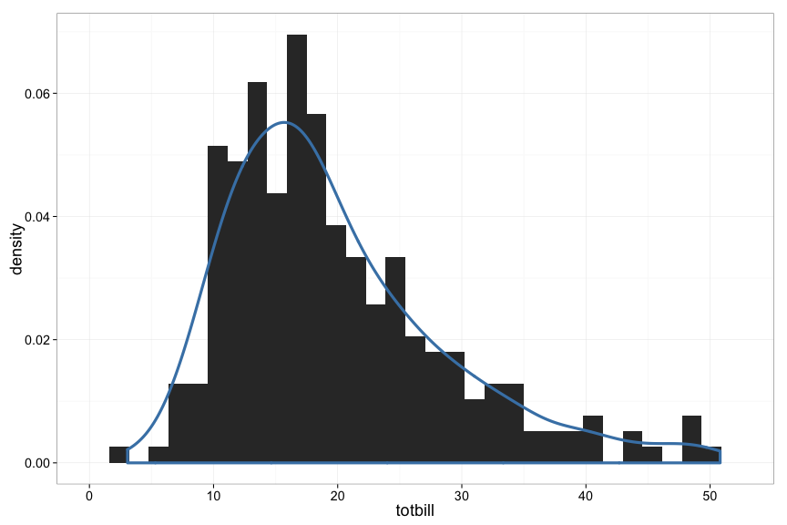

```r
ggplot(tips, aes(totbill)) +
  geom_histogram(aes(y = ..density..)) +
  geom_density(size=1.5, color="steelblue") +
  theme_bw(18)
```

### Example: legend and labels

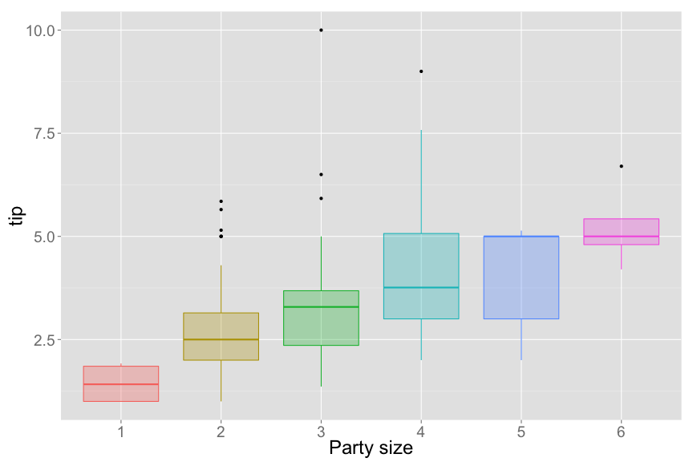

```r
ggplot(tips, aes(factor(size),tip,color=factor(size))) +
  geom_boxplot(aes(fill=factor(size)), alpha=0.3) +
  xlab("Party size") +
  theme(legend.position = "none")
```

### Reading assignment and references

- [The Grammar of Graphics](http://books.google.com/books/about/The_Grammar_of_Graphics.html?id=_kRX4LoFfGQC), by Leland Wilkinson.
- [ggplot2](http://www.springer.com/statistics/computational+statistics/book/978-0-387-98140-6), Elegant Graphics for Data Analysis by Hadley Wickham.
- `ggplot2` web site with nice documentation  
  http://docs.ggplot2.org/current/